# Alpha Diversity Estimation

By Angus Ball

Alpha diversity just got COMPLICATED Ill be merging these two tutorials, and honestly, they are going to be alot better than I could ever be so go give them a run through! I’m still gonna explain here so we have a S.O.P but when the author of the code offers to explain how to use it, don’t turn your nose https://github.com/adw96/DivNet/blob/main/vignettes/getting-started.Rmd https://adw96.github.io/breakaway/articles/breakaway.html https://github.com/adw96/breakaway/blob/main/vignettes/diversity-hypothesis-testing.Rmd

Irregardless lets go! start by uploading your data!

```r
filepulling <- "C:\\Users\\angus\\OneDrive - UNBC\\Angus Ball\\Lab work\\Bioinformatics\\Kenzies Data\\Kenzies data for michael\\physeq_Key_angusfixed2.rds" #add your file location here
physeq_Key <- readRDS(file = filepulling)
```

Then your packages

```r
library(DivNet)
library(phyloseq)
library(breakaway)
library(speedyseq)
library(magrittr)
library(tibble)
library(tidyverse)
```

This alpha diversity program assumes samples are from the same population of species (as they often are!) to estimate the true abundance of species and have an altogether more accurate alpha diversity metric. First things first, this is a taxing program to run so we are going to look at the order level, you can change this just as easy.

```r
physeq_order <- tax_glom(physeq_Key, taxrank="Order") #conglomerates everything to an order level
```

```r
physeq_order %>% sample_variables()
```

```
[1] "Sample_No" "Location"  "Layer"     "Treatment" "Site"      "Place"     "SeqTech"
```

We just combined all the taxonomy so the lowest level of depth is at an order level Now lets run the stats!

```r
#ouputobject <- physeq_object %>% divnet(tuning = fast or careful,
#                                          formula = ~ covariate + covariate)
set.seed(6458740)

divnet_order <- physeq_order %>% divnet(tuning = "careful")
divnet_order_Treatment <- physeq_order %>% divnet(tuning = "careful", formula = ~ Treatment)
divnet_order_Location <- physeq_order %>% divnet(tuning = "careful", formula = ~ Location)
divnet_order_Treatment_Location <- physeq_order %>% divnet(tuning = "careful", formula = ~ Treatment + Location)
divnet_order_Treatment_Location_Layer <- physeq_order %>% divnet(tuning = "careful", formula = ~ Treatment + Location + Layer) #only running this one because its the only one we think matters
divnet_order_Location_Layer <- physeq_order %>% divnet(tuning = "careful", formula = ~  Location + Layer)
```

Okay I just did alot of things, I get that, First things first. we are taking our physeq object and applying (%>%) the divnet command to it. We are apply this code at a “careful” level. i.e. this means more computing power is going into the equation and you’ll get a more accurate representation of the stats being done (you can also do this “fast” but uhh dont?). next is this formula stuff. Within data sets we have covariates (go search up and read what a covariate is now), and when microbial communities covary with say a location each sample reflects a part of the population that can be “combined” statistically so that we can estimate the total population diversity. I’m pretty sure the covariates within this dataset are treatment AND location AND Layer; however, we’re gonna run all of them just to see what happens! fun right?

PS. I set a seed because I’ll likely be rerunning code to make sure it works, and I dont want to go around changing my conclusions! PS2. This can take a half second to run

These take FIVE-EVER to run so Imma make and save copies of the objects

```r
divnetfiles <- "C:\\Users\\angus\\OneDrive - UNBC\\Angus Ball\\Lab work\\Bioinformatics\\Kenzies Data\\old stuff\\"
saveRDS(divnet_order, file = file.path(divnetfiles, "divnet_order.rds"))
saveRDS(divnet_order_Location, file = file.path(divnetfiles, "divnet_order_Location.rds"))
saveRDS(divnet_order_Treatment, file = file.path(divnetfiles,  "divnet_order_Treatment.rds"))
saveRDS(divnet_order_Treatment_Location, file = file.path(divnetfiles,"divnet_order_Treatment_Location.rds"))
saveRDS(divnet_order_Treatment_Location_Layer, file = file.path(divnetfiles,"divnet_order_Treatment_Location_Layer.rds"))
saveRDS(divnet_order_Location_Layer, file = file.path(divnetfiles,"divnet_order_Location_Layer.rds"))

divnet_order_Location_Layer <- readRDS(file = file.path(divnetfiles,"divnet_order_Location_Layer.rds"))
divnet_order_Treatment_Location <- readRDS(file = file.path(divnetfiles, "divnet_order_Treatment_Location.rds"))
divnet_order_Treatment <- readRDS(file = file.path(divnetfiles,"divnet_order_Treatment.rds"))
divnet_order_Location <- readRDS(file = file.path(divnetfiles,"divnet_order_Location.rds"))
divnet_order <- readRDS(file = file.path(divnetfiles,"divnet_order.rds"))
divnet_order_Treatment_Location_Layer <- readRDS(file = file.path(divnetfiles,"divnet_order_Treatment_Location_Layer.rds"))
```

Now lets plot it out! This is a plot of the raw diversity estimates for each sample with no covariate information shared across samples.

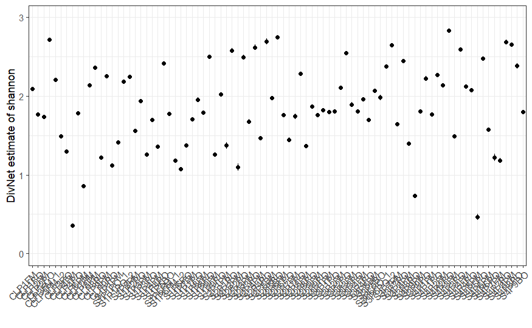

```r
divnet_order$shannon %>%
  plot(physeq_order)
```

look at that graph that means absolutely nothing to me! oh yeah

Now lets add some covariate info, treatments

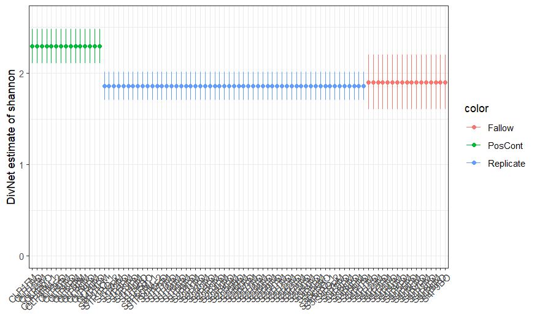

```r
divnet_order_Treatment$shannon %>%
  plot(physeq_order, color = "Treatment")
```

okay something more, how about location covariate info instead?

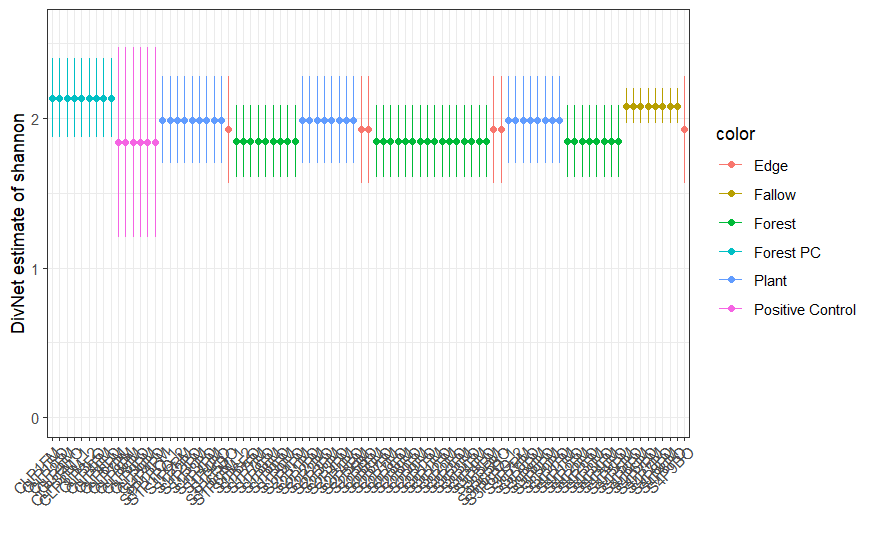

```r
divnet_order_Location$shannon %>%
  plot(physeq_order, color = "Location")
```

okay…okay, adding them together

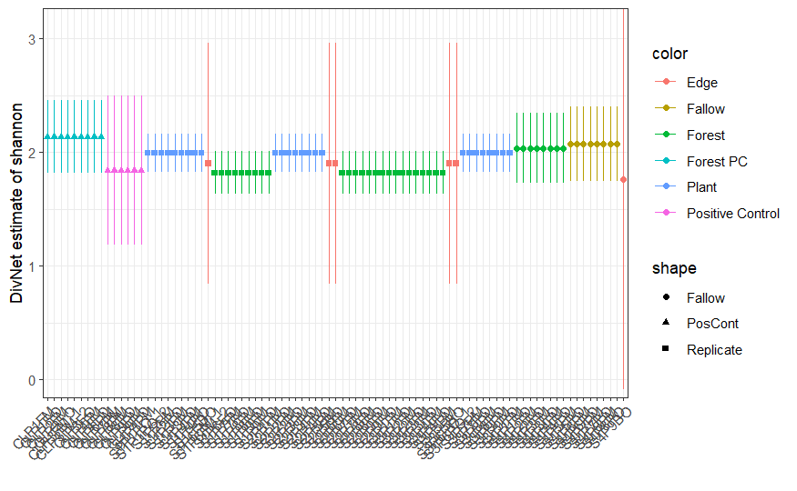

```r
divnet_order_Treatment_Location$shannon %>%
  plot(physeq_order, color = "Location", shape = "Treatment")
```

and finally with all of the covariate information

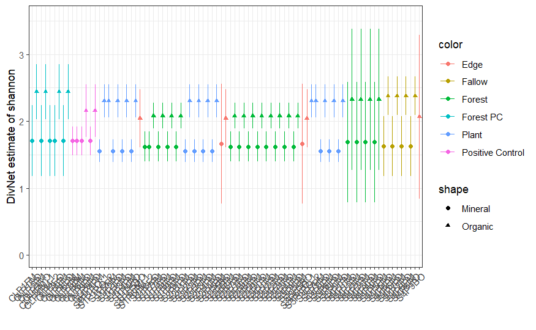

```r
divnet_order_Treatment_Location_Layer$shannon %>%
  plot(physeq_order, color = "Location", shape = "Layer")
```

But perhaps this is too much covariate information does fallow versus replicate really reflect unqiue and different covariates? perhaps no. This inlies a very important part of this kind of analysis. Since the answers you get are partially based on the covariates you choose, you need to be damned sure you choose the correct ones.

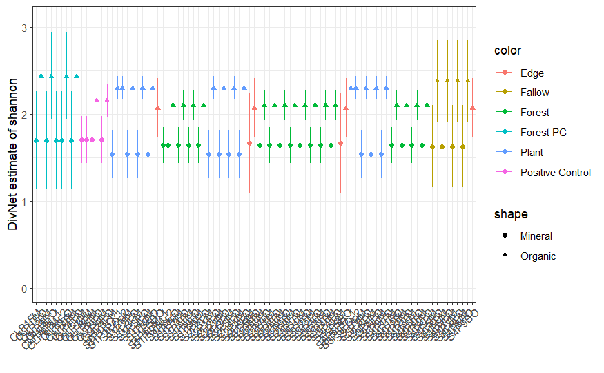

```r
divnet_order_Location_Layer$shannon %>%
  plot(physeq_order, color = "Location", shape = "Layer")
```

Based on that our analysis we be on data that includes location and layer covariates

this creates an object thats pretty much the key from phyloseq creation, we need it to hold on to metadata

```r
sample_data_key <- physeq_order %>%
  sample_data %>%
  tibble::as_tibble() %>%
  dplyr::mutate("sample_names" = physeq_order %>% sample_names )
```

lets run the test!, we need to make three objects to use this function, theyre just more objects that betta expects and we just need to bend to its will

```r
estimates <- divnet_order_Location_Layer$shannon %>% summary %$% estimate #this is where our shannon data is stored
ses <- sqrt(divnet_order_Location_Layer$`shannon-variance`) #take variance and turns it into standard error
X <- model.matrix(~Treatment, data = sample_data_key) #this creates a matrix that the model can use, its the sample sample_data_key but with numbers instead of words, also were we specify that we want to compare treatment
TLL_Treatment_betta <- betta(estimates, ses, X) # run the command
TLL_Treatment_betta$table #whats the p values
```

```
                      Estimates Standard Errors p-values
(Intercept)         1.940003783      0.03364096    0.000
TreatmentPosCont    0.015072262      0.09003531    0.867
TreatmentReplicate -0.004040079      0.04078468    0.921
```

```r
TLL_Location_betta_random <-
    betta_random(estimates, ses, X, groups = sample_data_key$Treatment )
TLL_Location_betta_random$table
```

```
                      Estimates Standard Errors p-values
(Intercept)         1.938068477      0.03320415    0.000
TreatmentPosCont    0.015162995      0.08112858    0.852
TreatmentReplicate -0.003309698      0.04229795    0.938
```

Hey whats betta_random and whys it different from betta/which one should you use? betta is said to be “A simple plotting interface for comparing total diversity across samples or a covariate gradient.” betta_random is “This function extends betta() to permit random effects modelling.” so what is fixed and random effects? well read: https://web.pdx.edu/~newsomj/mlrclass/ho_randfixd.pdf but briefly, fixed effects are independent variables that are measured without error, for example whether a sample was measured in a forest or a plantation. Random effects are independent variables that are drawn from a population thus representing a population and therefore random values around the population mean i.e. this dataset should use a fixed effect model as it is valid for betta which is a stronger model statistical than betta_random

Either way lets look at how the the model responds to the layer information

```r
estimates <- divnet_order_Location_Layer$shannon %>% summary %$% estimate #this is where our shannon data is stored
ses <- sqrt(divnet_order_Location_Layer$`shannon-variance`) #take variance and turns it into standard error
X <- model.matrix(~Layer, data = sample_data_key) #this creates a matrix that the model can use, its the sample sample_data_key but with numbers instead of words, also were we specify that we want to compare layers
TLL_Layer_betta <- betta(estimates, ses, X) # run the command
TLL_Layer_betta$table #whats the p values
```

```
             Estimates Standard Errors p-values
(Intercept)  1.6292022      0.01168101        0
LayerOrganic 0.5891731      0.01416913        0
```

This means that the organic layer has a significantly higher diversity than the mineral layer across all samples its total amount is (0.58+1.62).

Okay what if we wanted to compare multiple things at once? we know replicate versus fallow doesn’t matter, so lets just compare location and layer

```r
estimates <- divnet_order_Location_Layer$shannon %>% summary %$% estimate #this is where our shannon data is stored
ses <- sqrt(divnet_order_Location_Layer$`shannon-variance`) #take variance and turns it into standard error

X <- model.matrix(~Location*Layer, data = sample_data_key)#this is where we specify location and layer



TLL_Layer_Location_betta <- betta(estimates, ses, X, p.digits = 5) # run the command
TLL_Layer_Location_betta$table #whats the p values
```

```
                                        Estimates Standard Errors p-values
(Intercept)                            1.66939013      0.01090394  0.00000
LocationFallow                        -0.03562652      0.08321919  0.66857
LocationForest                        -0.02561327      0.01632864  0.11674
LocationForest PC                      0.03488587      0.08862756  0.69386
LocationPlant                         -0.12318836      0.01623102  0.00000
LocationPositive Control               0.03851131      0.04822450  0.42453
LayerOrganic                           0.40429978      0.01303620  0.00000
LocationFallow:LayerOrganic            0.34732128      0.11658520  0.00289
LocationForest:LayerOrganic            0.05674660      0.02143990  0.00813
LocationForest PC:LayerOrganic         0.33099816      0.12595408  0.00859
LocationPlant:LayerOrganic             0.35412853      0.01760813  0.00000
LocationPositive Control:LayerOrganic  0.04586626      0.06933592  0.50829
```

okay WHAT the fuck does this all mean? well fun fact this is the worst way to make a p value table known to man. Look at all the names in the intercept, which ones from your dataset are missing? Edge:mineral. That means edge:mineral is the intercept. so locationfallow is actually fallow:mineral, and layerorganic is actually edge:organic and so on. Estimates work the same way as before AND its still dumb. But regardless you can* use this table to make comparisons except there are two very important notes.

Firstly, why is edge:mineral first? its because its alphabetically first…. great. But we can change this by changing the factor, run the below commands and then rerun the betta exercise

```r
sample_data_key <- physeq_order %>%
  sample_data %>%
  tibble::as_tibble() %>%
  dplyr::mutate("sample_names" = physeq_order %>% sample_names )

sample_data_key <- sample_data_key %>% mutate(Location = factor(
  Location,
  levels=c("Forest", "Edge", "Fallow", "Forest PC", "Plant", "Positive Control")
))
#include all the datatypes in your column and order them the way you want the analysis to be conducted (in this example forest is now the intercept)

estimates <- divnet_order_Location_Layer$shannon %>% summary %$% estimate #this is where our shannon data is stored
ses <- sqrt(divnet_order_Location_Layer$`shannon-variance`) #take variance and turns it into standard error

X <- model.matrix(~Location*Layer, data = sample_data_key)#this is where we specify location and layer



TLL_Layer_Location_betta_forest <- betta(estimates, ses, X, p.digits = 5) # run the command
TLL_Layer_Location_betta_forest$table #whats the p values
```

```
                                        Estimates Standard Errors p-values
(Intercept)                            1.64377686      0.01090394  0.00000
LocationEdge                           0.02561327      0.07842806  0.74398
LocationFallow                        -0.01001325      0.08321919  0.90423
LocationForest PC                      0.06049914      0.08862756  0.49485
LocationPlant                         -0.09757509      0.01623102  0.00000
LocationPositive Control               0.06412458      0.04822450  0.18361
LayerOrganic                           0.46104638      0.01303620  0.00000
LocationEdge:LayerOrganic             -0.05674660      0.08484083  0.50359
LocationFallow:LayerOrganic            0.29057468      0.11658520  0.01269
LocationForest PC:LayerOrganic         0.27425156      0.12595408  0.02945
LocationPlant:LayerOrganic             0.29738194      0.01760813  0.00000
LocationPositive Control:LayerOrganic -0.01088034      0.06933592  0.87531
```

Secondly, betta does not account for the family wise error rate. ALSO great https://github.com/adw96/breakaway/issues/84

so whats there to be done?

```r
ptable <- TLL_Layer_Location_betta$table #start by separating the ptable from the weird betta object
ptable_adj <- ptable %>% #moving it to a new table bc reasons
  as.data.frame() %>%
  rename(p_values = "p-values") #removing the p-vlaues names because dashes mess stuff up later on
ptable_adj$p_values <- p.adjust(ptable_adj$p_values, method = "bonferroni") #apply whatever pvalue correction you'd like, bonferroni isn't a recommendation, but the first one I remembered off hand
ptable_adj
```

|  | Estimates | Standard Errors | p_values |
| --- | --- | --- | --- |
| (Intercept) | 1.66939013 | 0.01090394 | 0.00000 |
| LocationFallow | -0.03562652 | 0.08321919 | 1.00000 |
| LocationForest | -0.02561327 | 0.01632864 | 1.00000 |
| LocationForest PC | 0.03488587 | 0.08862756 | 1.00000 |
| LocationPlant | -0.12318836 | 0.01623102 | 0.00000 |
| LocationPositive Control | 0.03851131 | 0.04822450 | 1.00000 |
| LayerOrganic | 0.40429978 | 0.01303620 | 0.00000 |
| LocationFallow:LayerOrganic | 0.34732128 | 0.11658520 | 0.03468 |
| LocationForest:LayerOrganic | 0.05674660 | 0.02143990 | 0.09756 |
| LocationForest PC:LayerOrganic | 0.33099816 | 0.12595408 | 0.10308 |

[output cut: 2 more lines]

Sweet! now the p values have been adjusted and are valid as comparisons! But be very careful. Since the cut off earlier was at five digits some of these values were reported as zeros. These zeros will of course pass the bonferroni adjustment! so make sure you have enough zeros you’re comfortable with the adjusted p-table. PS. the intercept P value IS actually zero, so don’t worry about that (and technically you should remove it from this table before running the padjust, bc it isnt a real comparison)

dont forget to save your p-table!!!

```r
ptable <- TLL_Layer_Location_betta$table #start by separating the ptable from the weird betta object
ptable_adj <- ptable %>% #moving it to a new table bc reasons
  as.data.frame() %>%
  rename(p_values = "p-values") #removing the p-vlaues names because dashes mess stuff up later on
ptable_adj <- ptable_adj %>% filter(!row_number() %in% c(1))
ptable_adj$p_values <- p.adjust(ptable_adj$p_values, method = "bonferroni") #apply whatever pvalue correction you'd like, bonferroni isn't a recommendation, but the first one I remembered off hand
ptable_adj
```

|  | Estimates | Standard Errors | p_values |
| --- | --- | --- | --- |
| LocationFallow | -0.03562652 | 0.08321919 | 1.00000 |
| LocationForest | -0.02561327 | 0.01632864 | 1.00000 |
| LocationForest PC | 0.03488587 | 0.08862756 | 1.00000 |
| LocationPlant | -0.12318836 | 0.01623102 | 0.00000 |
| LocationPositive Control | 0.03851131 | 0.04822450 | 1.00000 |
| LayerOrganic | 0.40429978 | 0.01303620 | 0.00000 |
| LocationFallow:LayerOrganic | 0.34732128 | 0.11658520 | 0.03179 |
| LocationForest:LayerOrganic | 0.05674660 | 0.02143990 | 0.08943 |
| LocationForest PC:LayerOrganic | 0.33099816 | 0.12595408 | 0.09449 |
| LocationPlant:LayerOrganic | 0.35412853 | 0.01760813 | 0.00000 |

[output cut: 1 more lines]

yknow what? if there wasnt a value 8 digits under I think it might just be signifigant…

PS. heres the original issues page where I finally figured out how to read the intercept tables This makes the table 10x more unreadable and took me a whole ass day to find out https://github.com/adw96/DivNet/issues/34